# Iris Data

Parash Upreti

July 4, 2016

Loading Iris dataset from R base

```r
data(iris)
head(iris)
```

```
##   Sepal.Length Sepal.Width Petal.Length Petal.Width Species
## 1          5.1         3.5          1.4         0.2  setosa
## 2          4.9         3.0          1.4         0.2  setosa
## 3          4.7         3.2          1.3         0.2  setosa
## 4          4.6         3.1          1.5         0.2  setosa
## 5          5.0         3.6          1.4         0.2  setosa
## 6          5.4         3.9          1.7         0.4  setosa
```

```r
str(iris)
```

```
## 'data.frame':    150 obs. of  5 variables:
##  $ Sepal.Length: num  5.1 4.9 4.7 4.6 5 5.4 4.6 5 4.4 4.9 ...
##  $ Sepal.Width : num  3.5 3 3.2 3.1 3.6 3.9 3.4 3.4 2.9 3.1 ...
##  $ Petal.Length: num  1.4 1.4 1.3 1.5 1.4 1.7 1.4 1.5 1.4 1.5 ...
##  $ Petal.Width : num  0.2 0.2 0.2 0.2 0.2 0.4 0.3 0.2 0.2 0.1 ...
##  $ Species     : Factor w/ 3 levels "setosa","versicolor",..: 1 1 1 1 1 1 1 1 1 1 ...
```

Exploring Iris dataset

```r
summary(iris)
```

```
##   Sepal.Length    Sepal.Width     Petal.Length    Petal.Width
##  Min.   :4.300   Min.   :2.000   Min.   :1.000   Min.   :0.100
##  1st Qu.:5.100   1st Qu.:2.800   1st Qu.:1.600   1st Qu.:0.300
##  Median :5.800   Median :3.000   Median :4.350   Median :1.300
##  Mean   :5.843   Mean   :3.057   Mean   :3.758   Mean   :1.199
##  3rd Qu.:6.400   3rd Qu.:3.300   3rd Qu.:5.100   3rd Qu.:1.800
##  Max.   :7.900   Max.   :4.400   Max.   :6.900   Max.   :2.500
##        Species
##  setosa    :50
##  versicolor:50
##  virginica :50
##
##
##
```

```r
dim(iris)
```

```
## [1] 150   5
```

```r
cor.test(iris$Sepal.Length, iris$Petal.Length)
```

```
##
##  Pearson's product-moment correlation
##
## data:  iris$Sepal.Length and iris$Petal.Length
## t = 21.646, df = 148, p-value < 2.2e-16
## alternative hypothesis: true correlation is not equal to 0
## 95 percent confidence interval:
##  0.8270363 0.9055080
## sample estimates:
##       cor
## 0.8717538
```

```r
library(ggplot2)
```

Visualizing Iris dataset

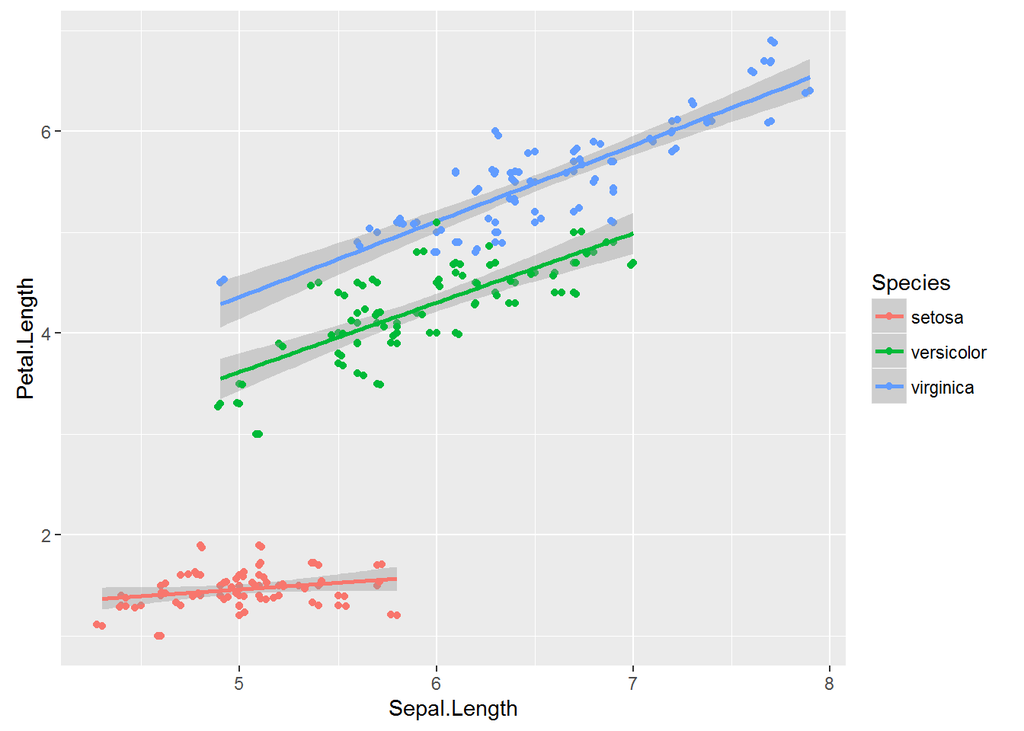

```r
#Scatterplot to visualize 3 variables

ggplot(iris, aes(x = Sepal.Length, y = Petal.Length,color = Species))+
  geom_point() + geom_smooth(method = lm)+ geom_jitter()
```

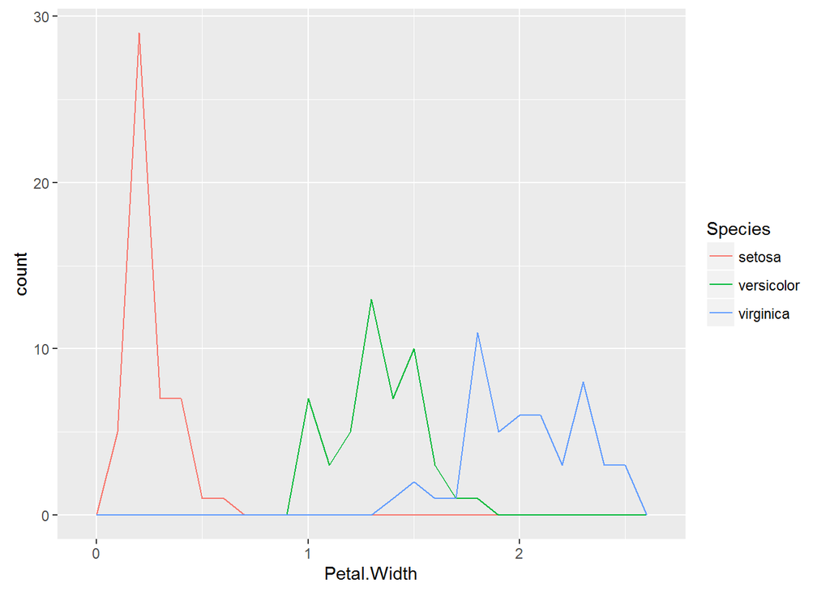

```r
#frequency polygon
ggplot(iris, aes(x = Petal.Width, color = Species))+ geom_freqpoly(binwidth =0.1)
```

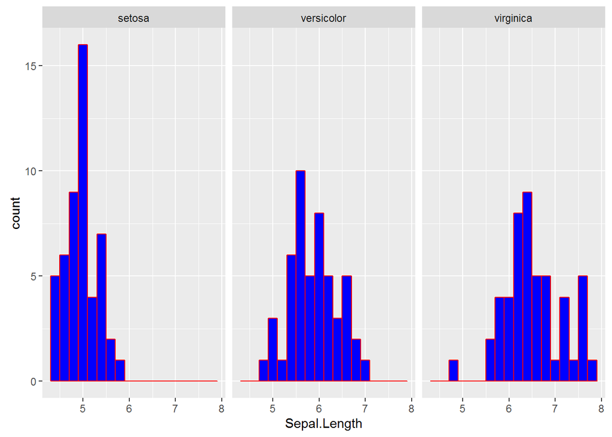

```r
#Histogram of Sepal Length by Species. visualizing two variables in histogram
ggplot(iris, aes(x= Sepal.Length))+ geom_histogram(col= "red", fill = I("blue"), binwidth = .2)+
  facet_wrap(~Species)
```

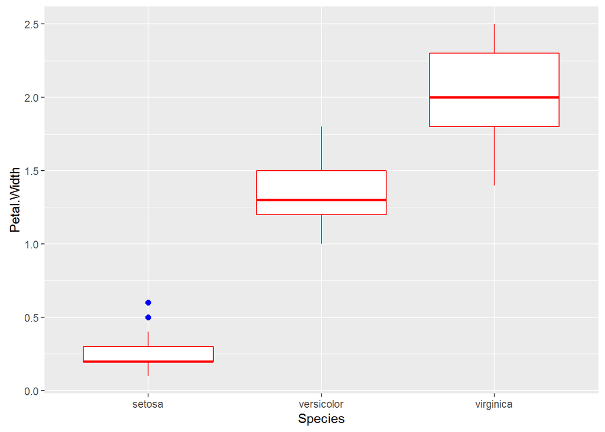

```r
#Box plot of Species by Petal Width. Visualizing two variables in boxplot
ggplot(iris, aes(x= Species, Petal.Width))+
  geom_boxplot(outlier.size = 2, outlier.color = "blue", color = "red")
```

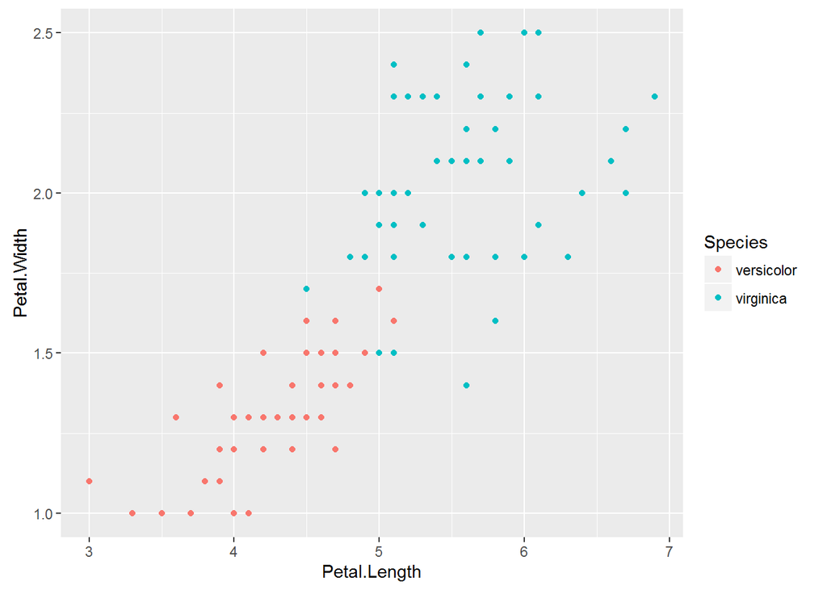

```r
ggplot(subset(iris, Petal.Length>=2.5 & Petal.Width>=1), aes(x = Petal.Length, y = Petal.Width))+
  geom_point(aes(color = Species))
```

Making simple predictions by using the information already available.

```r
#Total number of predictions Petal Width seperates Setosa from non Setosa
table(iris$Petal.Width<.9 , iris$Species)
```

```
##
##         setosa versicolor virginica
##   FALSE      0         50        50
##   TRUE      50          0         0
```

```r
table(subset(iris, Species =! "Setosa")$Petal.Length<4.75, iris$Species)
```

```
##
##         setosa versicolor virginica
##   FALSE      0          6        49
##   TRUE      50         44         1
```

```r
#Proprotions
prop.table(table(iris$Petal.Width>.9 & iris$Petal.Length >4.8, iris$Species))
```

```
##
##             setosa versicolor  virginica
##   FALSE 0.33333333 0.30666667 0.02000000
##   TRUE  0.00000000 0.02666667 0.31333333
```

## Using Decision Trees

Run the codes to see the output

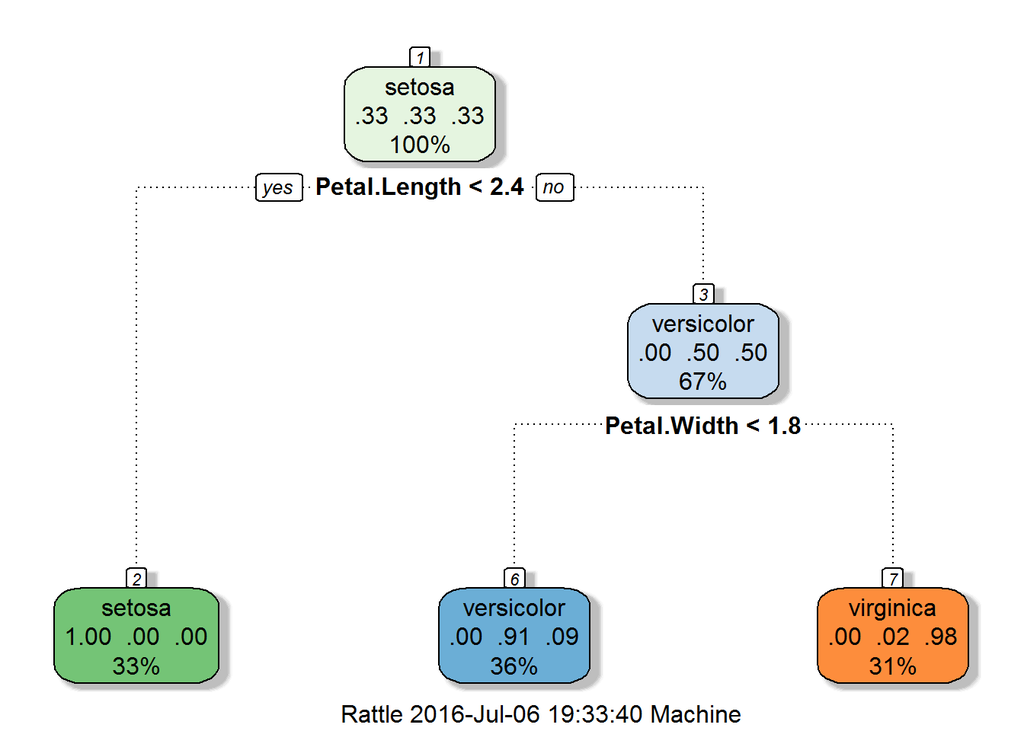

```r
library(rpart)
library(rpart.plot)
library(rattle)
library(RColorBrewer)

iris_tree<- rpart(Species~., data = iris)
fancyRpartPlot(iris_tree)
```

```r
basic_predict<- predict(iris_tree, newdata = iris[,-5], type = "class")
#summary(iris_tree)     #uncomment this code to see the details of the model
iris_tree$frame

#checking our accuracy of the prediction

table(iris$Species, basic_predict)
```

Model was trained by using Iris dataset and the same dataset was used to test the model by removing the Species column. It predicted correctly 0.96 times

Predicting using decision trees by splitting into training and testing

```r
set.seed(1221)
sampledata<- sample(nrow(iris), .75*(nrow(iris)))
iris_train<- iris[sampledata, ]
iris_test<- iris[-sampledata,]

dim(iris_train)
```

```
## [1] 112   5
```

```r
head(iris_train)
```

```
##     Sepal.Length Sepal.Width Petal.Length Petal.Width    Species
## 37           5.5         3.5          1.3         0.2     setosa
## 13           4.8         3.0          1.4         0.1     setosa
## 42           4.5         2.3          1.3         0.3     setosa
## 110          7.2         3.6          6.1         2.5  virginica
## 71           5.9         3.2          4.8         1.8 versicolor
## 143          5.8         2.7          5.1         1.9  virginica
```

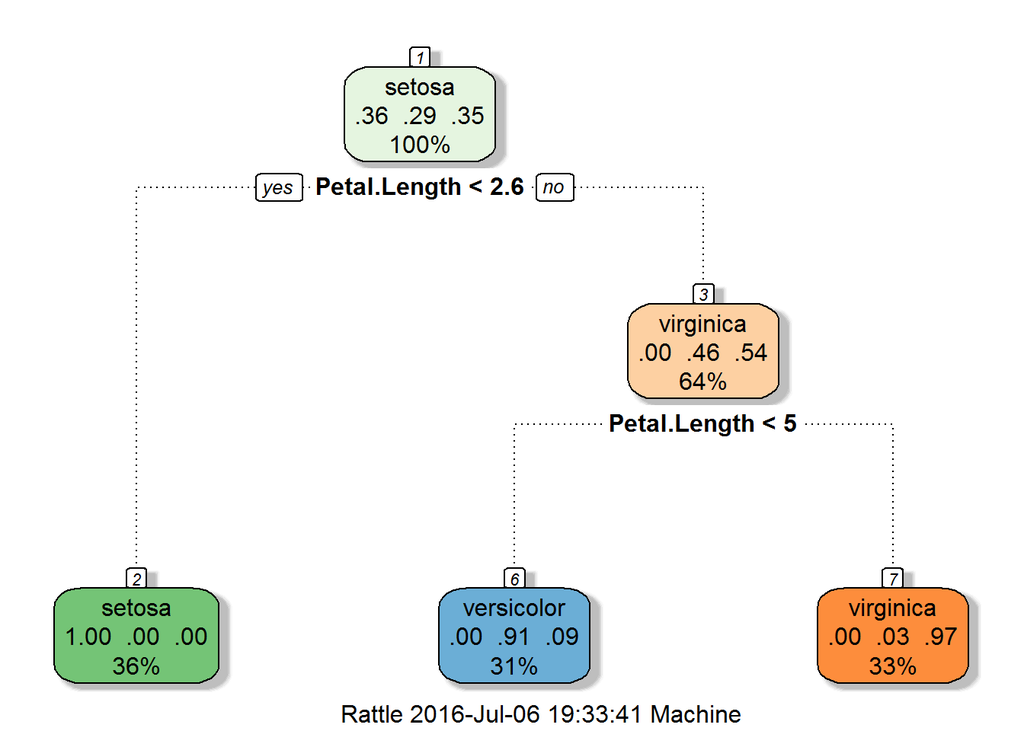

```r
iris_1_tree<-rpart(Species~., data = iris_train, control = rpart.control(cp = 0.04, minsplit = 5))
fancyRpartPlot(iris_1_tree)
```

```r
iris_1_predict <- predict(iris_1_tree, newdata = iris_test[,-5], type = "class")

sum(diag(table(iris_test$Species, iris_1_predict)))/38
```

```
## [1] 0.8947368
```

```r
#exact binomial test

binom.test(sum(diag(table(iris_test$Species, iris_1_predict))), 38)
```

```
##
##  Exact binomial test
##
## data:  sum(diag(table(iris_test$Species, iris_1_predict))) and 38
## number of successes = 34, number of trials = 38, p-value =
## 6.039e-07
## alternative hypothesis: true probability of success is not equal to 0.5
## 95 percent confidence interval:
##  0.7519506 0.9705655
## sample estimates:
## probability of success
##              0.8947368
```

### N-fold cross validation

Cross validation helps identify if the model is overfitted or underfitted. Overfitting the model makes it too complex and will have low training error but high generalization erros and underfitting makes it too general and will have high training and generaliztion error.

Cross Validating the predictions using simulations of 20 different random samples

```r
confmatrix<- function(y, predy){
    matrix= table(y, predy)
    accuracy= sum(diag(matrix))/sum(matrix)
    return(list(matrix = matrix, accuracy = accuracy, error = 1- accuracy))
}

#creating folds of data (literally folding the given data in n layers)

createfolds<- function(n,X){
    reps = ceiling(n/X)
    folds = sample(rep(1:X,reps))
    return(folds[1:n])
}
folds = createfolds(nrow(iris), 20)
accvect<- 1:20   #empty vector to store data from simulation

#Looping through the data to replicate/simulate models

for (k in 1:20){
  temptest<- iris[folds==k,]
  temptrain<- iris[folds!=k,]

  temptree<- rpart(Species~., data = temptrain, control = rpart.control(cp= 0.01))
  accvect[k]<- confmatrix(temptest$Species,
                          predict(temptree, newdata = temptest[-5], type = "class"))$accuracy
}
summary(accvect)
```

```
##    Min. 1st Qu.  Median    Mean 3rd Qu.    Max.
##  0.7500  0.8705  1.0000  0.9336  1.0000  1.0000
```

This 20-fold cross validation showed that 12 out of 20 instances had perfect predictions

### Bootstrapping Cross Validation

Bootstrapping is random sampling with replacement. Same idea as n-fold cv, to create multiple test and train instances and see how well the model performs overall

```r
accvect_2<- 1:20

for (k in 1:20){
  temptest<- iris[sample(nrow(iris),30, replace = T),]
  temptrain<- iris[sample(nrow(iris),(nrow(iris)-30), replace = T),]

  temptree<- rpart(Species~., data = temptrain, control = rpart.control(cp= 0.01))
  accvect_2[k]<- confmatrix(temptest$Species,
                          predict(temptree, newdata = temptest[-5], type = "class"))$accuracy
}
summary(accvect_2)
```

```
##    Min. 1st Qu.  Median    Mean 3rd Qu.    Max.
##  0.9000  0.9333  0.9667  0.9633  1.0000  1.0000
```